# Lab4_LilRascals

## James’ Plot

```r
library(tidyverse)
babies <- read_csv("https://raw.githubusercontent.com/ervance1/Sp2018-Data-Science-repo/master/babies2a.dat")
```

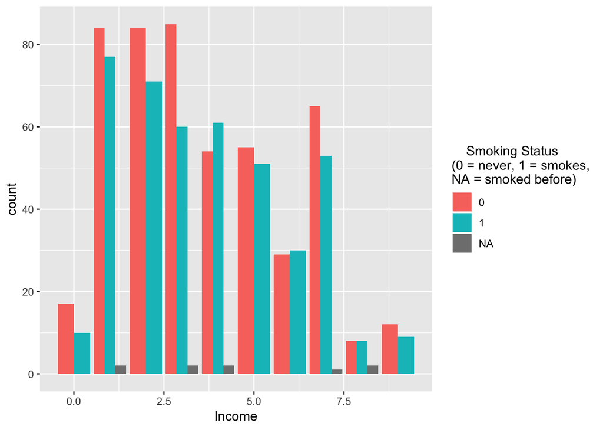

```r
ggplot(data = babies) +
  geom_bar(mapping = aes(x = inc, fill = as.factor(smoke)), position = position_dodge()) +
  xlab("Income")+
  scale_fill_discrete(name = "    Smoking Status
(0 = never, 1 = smokes,
NA = smoked before)")
```

James’ Question: Does income affect the proportion of those who smoke, and those who do not smoke?

James’ Findings: I found that for the most part a families income does not affect whether or not they smoke. For most income groups the proportion of people who never smoke is greater than that of the proportion of people who smoke.

## Matt’s PLot

```r
babies <- read_csv("https://raw.githubusercontent.com/ervance1/Sp2018-Data-Science-repo/master/babies2a.dat")
```

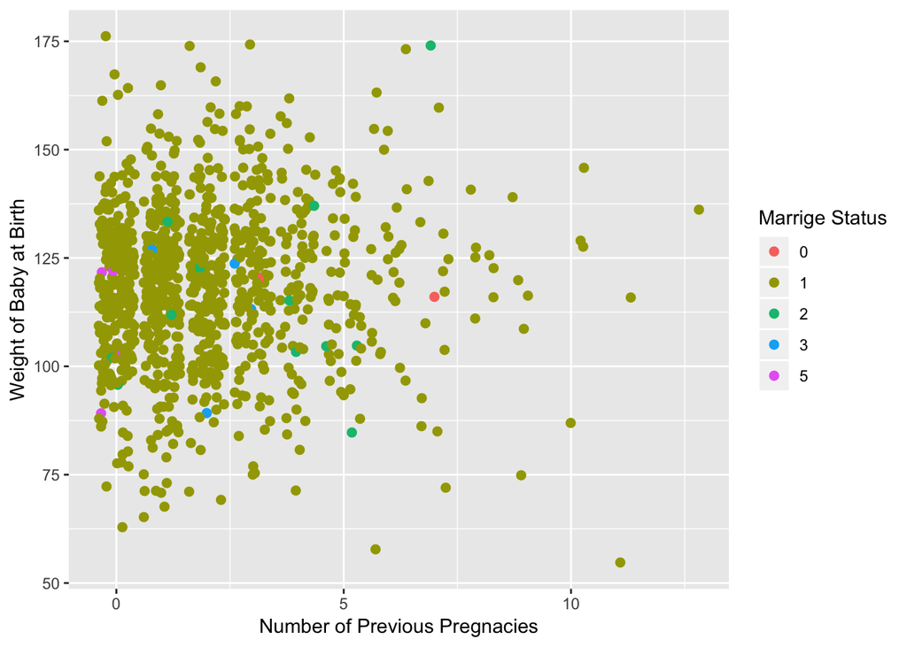

```r
babies <- rename(babies, bwtoz = `bwt/oz`) #renaming `bwt/oz` because the "/" sign requires special care
ggplot(data = babies)+
  geom_jitter(aes(x = parity, y = bwtoz, color = as.factor(marital)),size = 2, na.rm = TRUE)+
  scale_fill_discrete(name = "marrige staus")+
  xlab("Number of Previous Pregnacies")+
  ylab("Weight of Baby at Birth")+
  guides(color=guide_legend("Marrige Status"))
```

Matt’s Question: Does a mother having more previous babies affect the other babies after that first one?

Matt’s Findings: After looking at the data, babies are born at an average weight by the mothers first couple but as the mother has more babies then the data scatters out and becomes unpredictable.